# Custom palette

We can create a personal palette for our charts. While there are many utilities to create palettes, in order to apply consistent colouring schemes in different charts, it is useful to create a personal one. We will create one for our purposes, one with Eurostat’s theme colours and some others that can be easily updated.

We will follow the steps explained in this tutorial https://drsimonj.svbtle.com/creating-corporate-colour-palettes-for-ggplot2 and using the Eurostat stly guide https://ec.europa.eu/eurostat/documents/4187653/7192088/STYLE_GUIDE_2016.pdf/dbdf7b92-5ac5-4313-ae80-296f52692e5c?t=1457450262000. We will need to follow these steps:

1.Named vector of hex codes for the colors (`luis_colours`). 1.Function to access hex codes (in 1) (`luis_cols`). 1.Named list of color palettes (`luis_palettes`). 1.Function to access palettes and interpolate(`luis_pal`). 1.ggplot2-compatible scale functions that use the palettes (`scale_colour_luis`, `scale_fill_luis`)

## luis_colours

First, we create a vector of colours and names for the colours. I include Eurostat’s theme colours. According to the style guide https://ec.europa.eu/eurostat/documents/4187653/7192088/STYLE_GUIDE_2016.pdf/dbdf7b92-5ac5-4313-ae80-296f52692e5c?t=1457450262000 these are the theme colours.

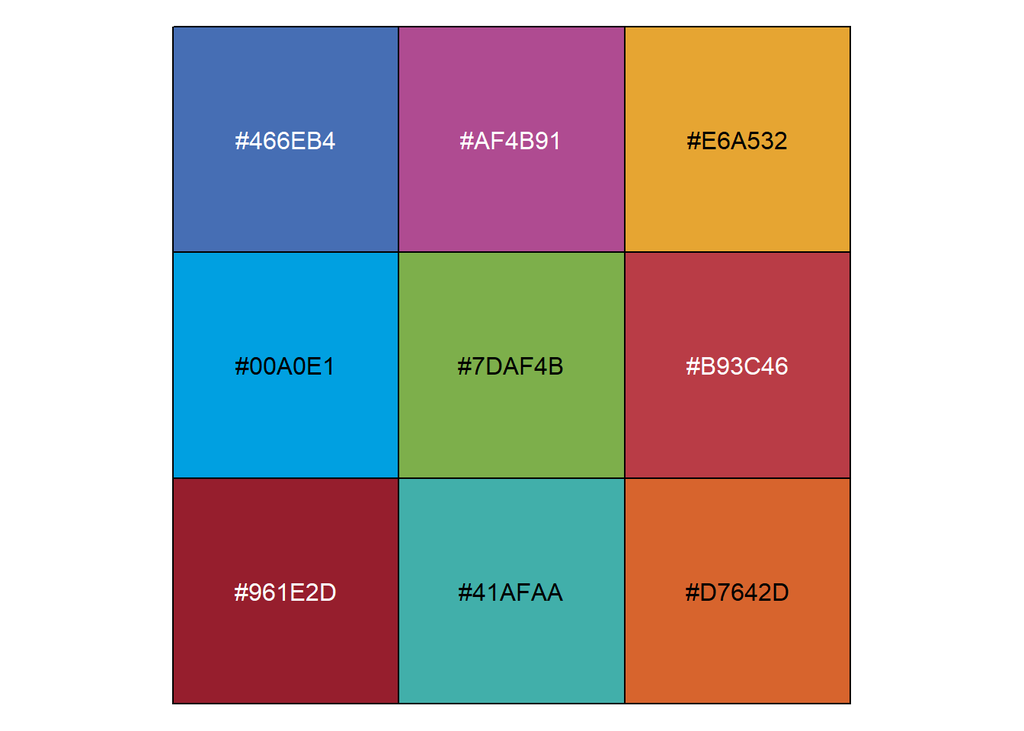

```r
library(tidyverse)
eurostat_colours <- c('theme1' = "#466EB4",
                 'theme2' = "#AF4B91",
                 'theme3' = "#E6A532",
                 'theme4' = "#00A0E1",
                 'theme5' = "#7DAF4B",
                 'theme6' = "#B93C46",
                 'theme7' = "#961E2D",
                 'theme8' = "#41AFAA",
                 'theme9' = "#D7642D")

scales::show_col(eurostat_colours)
```

I am going to change the order (which does not have any effect here but it is the order I have chosen)and add other colours.

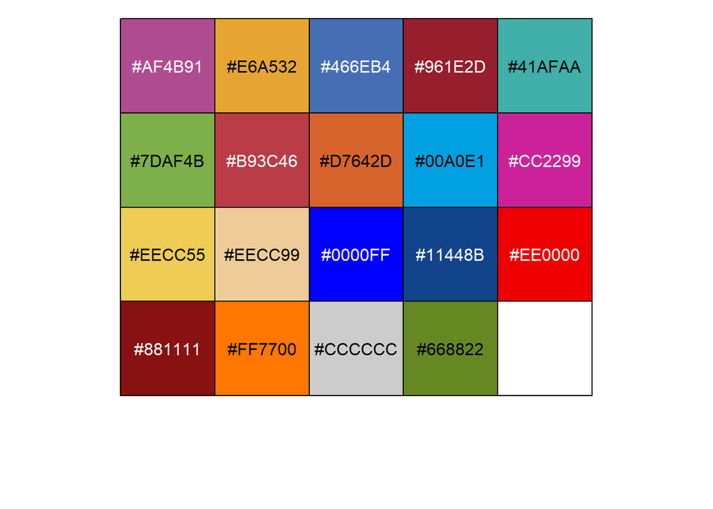

```r
library(tidyverse)
luis_colours <- c('theme2' = "#AF4B91",
                   'theme3' = "#E6A532",
                   'theme1' = "#466EB4",
                   'theme7' = "#961E2D",
                   'theme8' = "#41AFAA",
                   'theme5' = "#7DAF4B",
                   'theme6' = "#B93C46",
                   'theme9' = "#D7642D",
                   'theme4' = "#00A0E1",
                   'fucsia' = "#CC2299",
                   'yellow' = "#EECC55",
                   'brown' = "#EECC99",
                   'blue' = "#0000FF",
                   'blue1' = "#11448B",
                   'red' = "#EE0000",
                   'red1' = "#881111",
                   'orange' = "#FF7700",
                   'grey' = "#CCCCCC",
                   'green' = "#668822")

scales::show_col(luis_colours)
```

## luis_cols

We create a function to extract the HEX colour codes from the name.

```r
#' Function to extract  colors as hex codes
#'
#' @param ... Character names of colors
#'
luis_cols <- function(...) {
  cols <- c(...)

  if (is.null(cols)) {
    return(luis_colours)
  }

  luis_colours[cols]
}

luis_cols("theme2")
```

```
##    theme2
## "#AF4B91"
```

We can already use it setting manually the colour.

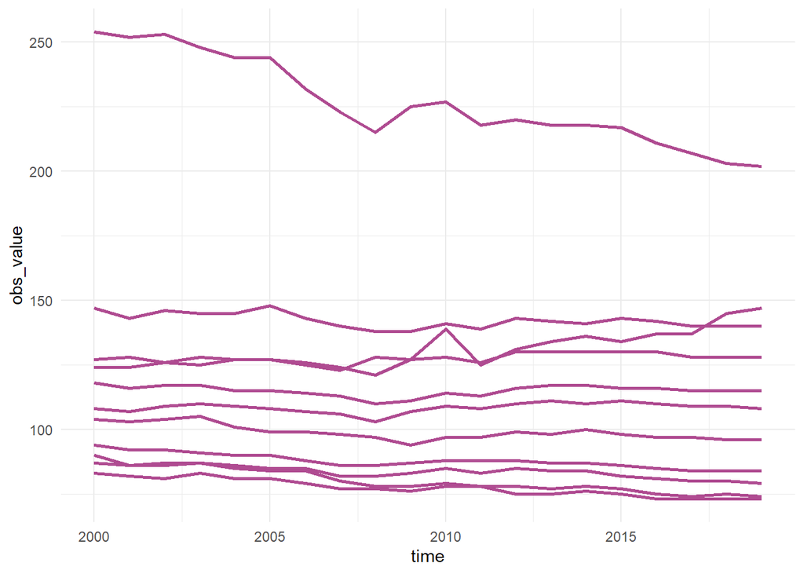

```r
df<- data.table::fread("data/gdp2v.csv") %>%
  filter(unit=="PPS_HAB_EU27_2020") %>%
  mutate(country=str_sub(geo,1,2),
         NUTS=str_length(geo)-2) %>%
  filter(NUTS=="2" & country =="BE") %>%
  select(-obs_decimals,-obs_status, -unit,-NUTS)

ggplot(df, aes(time,obs_value, group = geo))+
  geom_line(size=1, colour = luis_cols("theme2"))+
  theme_minimal()
```

## luis_palettes

Now we create a list of combination of the colours defined. We will create the three palettes described in the Eurostat style guide

```r
luis_palettes <- list('palette1' = luis_cols("theme8",
                                             "theme4",
                                             "theme1",
                                             "theme3",
                                             "theme9"),
                      'palette2' = luis_cols("theme5",
                                             "theme7",
                                             "theme1",
                                             "theme3",
                                             "theme9"),
                      'palette3' = luis_cols("theme8",
                                             "theme7",
                                             "theme1",
                                             "theme2",
                                             "theme6")
)
```

## luis_pal

We create a function to interpolate the colours automatically when we need more than the ones available in the palette.

```r
#' Return function to interpolate a  color palette
#'
#' @param palette Character name of palette in luis_palettes
#' @param reverse Boolean indicating whether the palette should be reversed
#' @param ... Additional arguments to pass to colorRampPalette()
#'
luis_pal<- function (palette= "palette1",
                     reverse = FALSE, ...) {
  pal <- luis_palettes[[palette]]
  if (reverse) pal <- rev (pal)
  colorRampPalette(pal,...)
}
```

This function gets a palete by name from the list (“palette1” by default), has a boolean condition determining whether to reverse the order or not, and additional arguments to pass on to colorRampPallete() (such as an alpha value).

```r
luis_pal("palette1")
```

```
## function (n)
## {
##     x <- ramp(seq.int(0, 1, length.out = n))
##     if (ncol(x) == 4L)
##         rgb(x[, 1L], x[, 2L], x[, 3L], x[, 4L], maxColorValue = 255)
##     else rgb(x[, 1L], x[, 2L], x[, 3L], maxColorValue = 255)
## }
## <bytecode: 0x00000000210937a8>
## <environment: 0x000000002108c3c0>
```

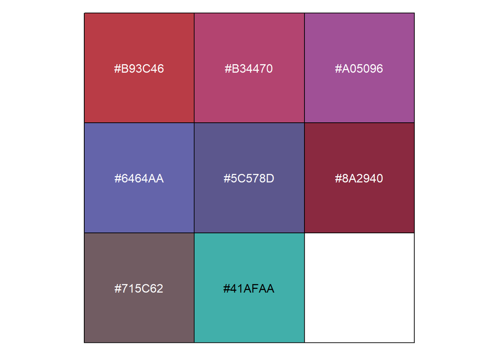

```r
scales::show_col(luis_pal("palette3",reverse=TRUE)(8))
```

## scale_colour_luis & scale_fill_luis

Finally, we create a function to be used in ggplot scales.

```r
#' Color scale constructor for luis colors
#'
#' @param palette Character name of palette in luis_palettes
#' @param discrete Boolean indicating whether color aesthetic is discrete or not
#' @param reverse Boolean indicating whether the palette should be reversed
#' @param ... Additional arguments passed to discrete_scale() or
#'            scale_color_gradientn(), used respectively when discrete is TRUE or FALSE
#'
scale_colour_luis <- function(palette = "palette1", discrete = TRUE, reverse = FALSE, ...) {
  pal <- luis_pal(palette = palette, reverse = reverse)

  if (discrete) {
    discrete_scale("colour", paste0("luis_", palette), palette = pal, ...)
  } else {
    scale_color_gradientn(colours = pal(256), ...)
  }
}

#' Fill scale constructor for luis colors
#'
#' @param palette Character name of palette in luis_palettes
#' @param discrete Boolean indicating whether color aesthetic is discrete or not
#' @param reverse Boolean indicating whether the palette should be reversed
#' @param ... Additional arguments passed to discrete_scale() or
#'            scale_fill_gradientn(), used respectively when discrete is TRUE or FALSE
#'
scale_fill_luis <- function(palette = "palette1", discrete = TRUE, reverse = FALSE, ...) {
  pal <- luis_pal(palette = palette, reverse = reverse)

  if (discrete) {
    discrete_scale("fill", paste0("luis_", palette), palette = pal, ...)
  } else {
    scale_fill_gradientn(colours = pal(256), ...)
  }
}
```

Each of these functions specifies a palette, whether the palette is being applied based on a discrete or numeric variable, whether to reverse the palette colors, and additional arguments to pass to the relevant ggplot2 function (which differs for discrete or numeric mapping).

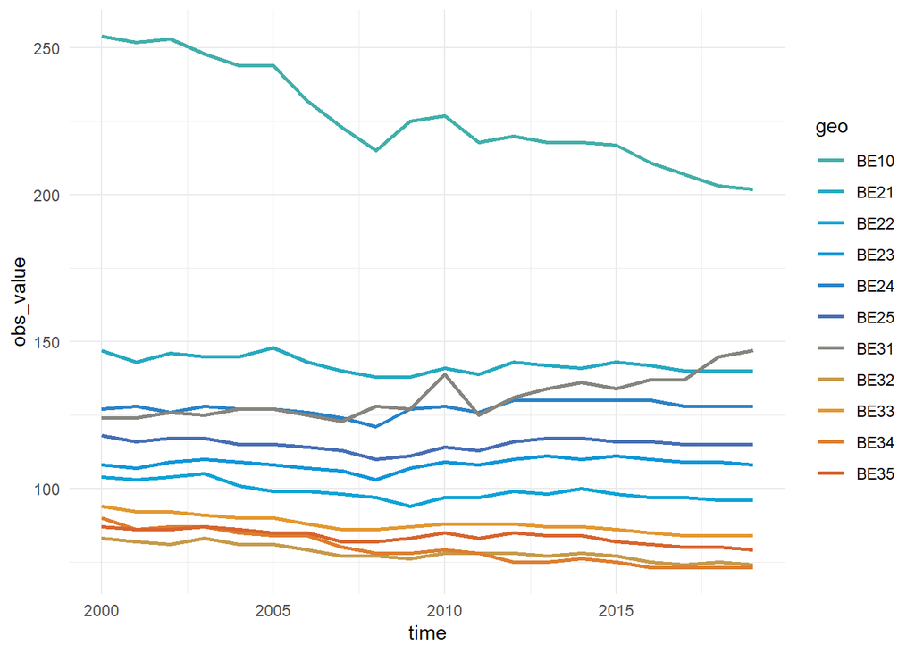

```r
ggplot(df, aes(time,obs_value, colour = geo))+
  geom_line(size=1)+
  theme_minimal()+
  scale_colour_luis()
```

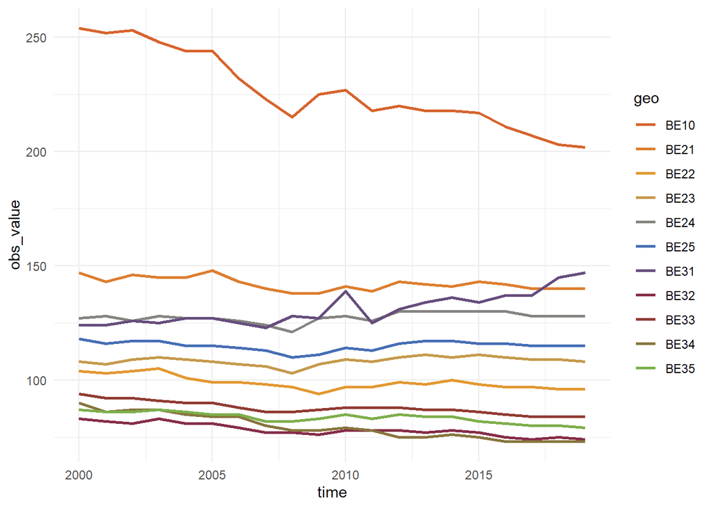

```r
ggplot(df, aes(time,obs_value, colour = geo))+
  geom_line(size=1)+
  theme_minimal()+
  scale_colour_luis(palette = "palette2", reverse = TRUE)
```

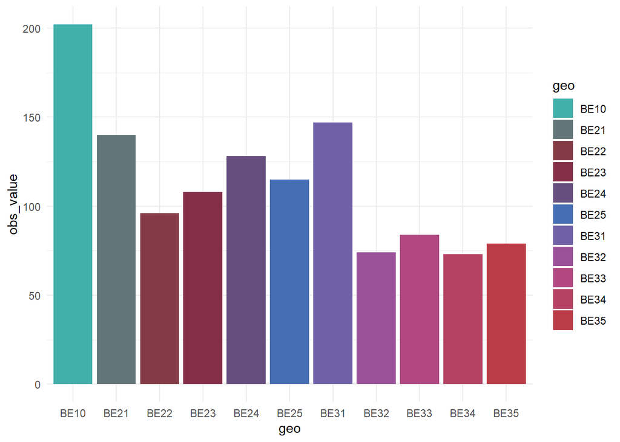

```r
ggplot(df %>% filter(time =="2019"), aes(geo,obs_value, fill = geo))+
  geom_col()+
  theme_minimal()+
  scale_fill_luis(palette="palette3")
```